# Trabajo FInal

Ariel Massini

5/10/2019

En este trabajo se exploran algunos indicadores básicos respecto al mercado de trabajo. Se trabajará con el EPH primer trimestre 2017.

En primer lugar se procede a abrir el archivo y bajar el paquete tidyverse.

```r
setwd("C:/Users/Usuario/Documents/curso reph/trabajo")
data<-read.csv("usu_individual_t117.txt", sep=";")
library(tidyverse)
```

En primer lugar se analiza la informalidad segun sector de actividad económica, ya que existe una vasta literatura en la que se muestra que las tasas de informalidad suelen ser muy heterogeneas. En primer lugar, utilizando el clasificador CAES 2001 Mercosur se designan una serie de sectores económicos.

```r
data <- data %>%
  mutate(sector_actividad=case_when(
    PP04B_COD %in% c(0101:0300) ~ "Agricultura",
    PP04B_COD %in% c(0500:0900) ~ "Minería",
    PP04B_COD %in% c(1001:3300) ~ "Manufactura",
    PP04B_COD %in% c(3501:3900) ~ "Elec Gas Agua",
    PP04B_COD==4000 ~ "Construcción",
    PP04B_COD %in% c(4501:4811) ~ "Comercio",
    PP04B_COD %in% c(4901:5300) ~ "Transporte",
    PP04B_COD %in% c(5500:5602) ~ "Hoteles y Restaurantes",
    PP04B_COD %in% c(5800:6300) ~ "Comunicaciones",
    PP04B_COD %in% c(6400:6600) ~ "Serv Financieros",
    PP04B_COD== 6800 ~ "Serv Inmobiliarios",
    PP04B_COD %in% c(6900:7500) ~ "Serv Profesionales",
    PP04B_COD %in% c(7701:8200) ~ "Serv Administrativos",
    PP04B_COD %in% c(8300:8403) ~ "Adm Pública",
    PP04B_COD %in% c(8501:8509) ~ "Educacion",
    PP04B_COD %in% c(8600:8800) ~ "Salud",
    PP04B_COD %in% c(9000:9302) ~ "Ocio",
    PP04B_COD %in% c(9401:9609) ~ "Otros Servicios",
    PP04B_COD %in% c(9700:9800) ~ "Serv Domestico",
    PP04B_COD==9900 ~ "Org Extraterritorial"))
```

En segundo luga, procedemos a calcular la tasa de informalidad por sector de actividad económica de acuerdo a como los definimos previamente.

```r
informalidad_sector <- data %>%
  filter(PP04B_COD %in% c(0101:9900)) %>%
  group_by(sector_actividad)%>%
  summarise(Formales          = sum(PONDERA[ESTADO == 1 & PP07H==1]),
            Informales      = sum(PONDERA[ESTADO == 1 & PP07H==2]),
            Tasa_Formalidad                  = Formales/(Formales+Informales),
            Tasa_Informalidad               = Informales/(Formales+Informales)) %>%
  select(-c(2:3)) %>%
  mutate(Tasa_Formalidad=round(Tasa_Formalidad,2),
         Tasa_Informalidad=round(Tasa_Informalidad,2))

informalidad_sector
```

```
## # A tibble: 20 x 3
##    sector_actividad       Tasa_Formalidad Tasa_Informalidad
##    <chr>                            <dbl>             <dbl>
##  1 Adm Pública                      0.92               0.08
##  2 Agricultura                      0.570              0.43
##  3 Comercio                         0.580              0.42
##  4 Comunicaciones                   0.89               0.11
##  5 Construcción                     0.3                0.7
##  6 Educacion                        0.94               0.06
##  7 Elec Gas Agua                    0.85               0.15
##  8 Hoteles y Restaurantes           0.55               0.45
##  9 Manufactura                      0.72               0.28
## 10 Minería                          0.99               0.01
## 11 Ocio                             0.52               0.48
## 12 Org Extraterritorial             1                  0
## 13 Otros Servicios                  0.61               0.39
## 14 Salud                            0.83               0.17
## 15 Serv Administrativos             0.73               0.27
## 16 Serv Domestico                   0.25               0.75
## 17 Serv Financieros                 0.91               0.09
## 18 Serv Inmobiliarios               0.59               0.41
## 19 Serv Profesionales               0.570              0.43
## 20 Transporte                       0.580              0.42
```

Como podemos observar existe una gran disparidad en cuanto las tasas de informalidad presentadas por los sectores de actividad económica. Si exceptuamos a la agricultura, podemos afirmar que buena parte de la informalidad esta explicada por los sectores de servicios y la construcción.

Podemos ver estos resultados gráficamente

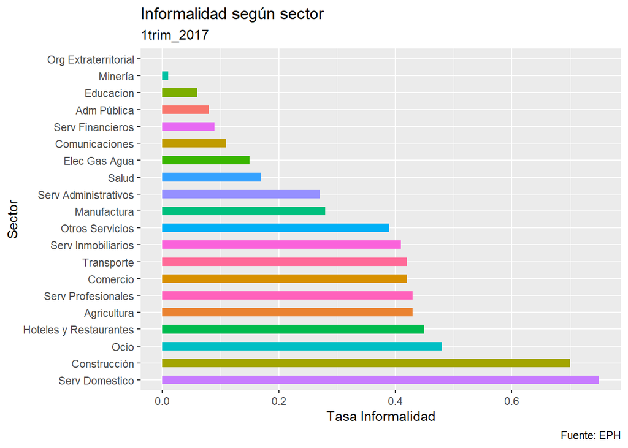

```r
grafico1<-ggplot(informalidad_sector, aes(x=reorder(sector_actividad,-Tasa_Informalidad),y=Tasa_Informalidad, fill=sector_actividad))+
  geom_bar(stat="identity", width=0.5)+
  labs(x = "Sector",
       y = "Tasa Informalidad",
       title = "Informalidad según sector",
       subtitle = "1trim_2017",
       caption = "Fuente: EPH")+
  theme(legend.position = 'none')

grafico1+ coord_flip()
```

Un dato llamativo es la alta informalidad presentada por sectores de servicios profesionales y actividades inmobiliarias.

En la segunda parte del trabajo se analiza la EPH tanto de una perspectiva sectorial como de género.

En primer lugar se calculan las tasas básicas del mercado de trabajo según género.

```r
genero <- data %>%
  group_by(CH04) %>%
  summarise(Poblacion         = sum(PONDERA),
            Ocupados          = sum(PONDERA[ESTADO == 1]),
            Desocupados       = sum(PONDERA[ESTADO == 2]),
            PEA               = Ocupados + Desocupados,
            Tasa_Actividad                  = PEA/Poblacion,
            Tasa_Empleo                     = Ocupados/Poblacion,
            Tasa_Desocupacion               = Desocupados/PEA)%>%
  select(-c(2:5)) %>%
  mutate(Tasa_Actividad=sprintf("%1.1f%%", 100*Tasa_Actividad),
         Tasa_Empleo=sprintf("%1.1f%%", 100*Tasa_Empleo),
         Tasa_Desocupacion=sprintf("%1.1f%%", 100*Tasa_Desocupacion),
         CH04 = case_when(CH04 == 1 ~ "Varon",
                          CH04 == 2 ~ "Mujer"))

genero
```

```
## # A tibble: 2 x 4
##   CH04  Tasa_Actividad Tasa_Empleo Tasa_Desocupacion
##   <chr> <chr>          <chr>       <chr>
## 1 Varon 54.3%          49.8%       8.5%
## 2 Mujer 37.3%          33.5%       10.2%
```

Como podemos observar las mujeres tienen una menor participación en el mercado de trabajo y están más afectadas por la desocupación.

Por otro lado, estudiamos como se distrbuyen los ocupados según los sectores de actividad.

```r
ocupados_sector<-data %>%
  filter(ESTADO==1, PP04B_COD %in% c(0101:9900))%>%
  group_by(sector_actividad)%>%
  summarise(Ocupados_sector    =sum(PONDERA))%>%
  mutate(Participacion= Ocupados_sector/sum(Ocupados_sector)) %>%
  select(1,3) %>%
  mutate(Participacion=sprintf("%1.1f%%", 100*Participacion))

ocupados_sector
```

```
## # A tibble: 20 x 2
##    sector_actividad       Participacion
##    <chr>                  <chr>
##  1 Adm Pública            8.6%
##  2 Agricultura            0.5%
##  3 Comercio               18.1%
##  4 Comunicaciones         1.7%
##  5 Construcción           9.2%
##  6 Educacion              8.1%
##  7 Elec Gas Agua          0.9%
##  8 Hoteles y Restaurantes 4.0%
##  9 Manufactura            11.9%
## 10 Minería                0.3%
## 11 Ocio                   1.9%
## 12 Org Extraterritorial   0.1%
## 13 Otros Servicios        3.4%
## 14 Salud                  6.5%
## 15 Serv Administrativos   4.5%
## 16 Serv Domestico         7.5%
## 17 Serv Financieros       2.0%
## 18 Serv Inmobiliarios     0.6%
## 19 Serv Profesionales     4.5%
## 20 Transporte             6.0%
```

Como podemos observar, los sectores que más ocupan son Comercio, industria Manufacturera y Construcción.

Resulta interesante analizar en que sectores de actividad se encuentran empleados varones y mujeres, ya que existe una vasta literatura que establece que las mujeres tienen una ventaja comparativa en actividades de servicio mientras que los varones la tienen en actividades industriales. Estudiemos, entonces, como se distribuyen tanto varones como mujeres en los diferentes sectores de actividad.

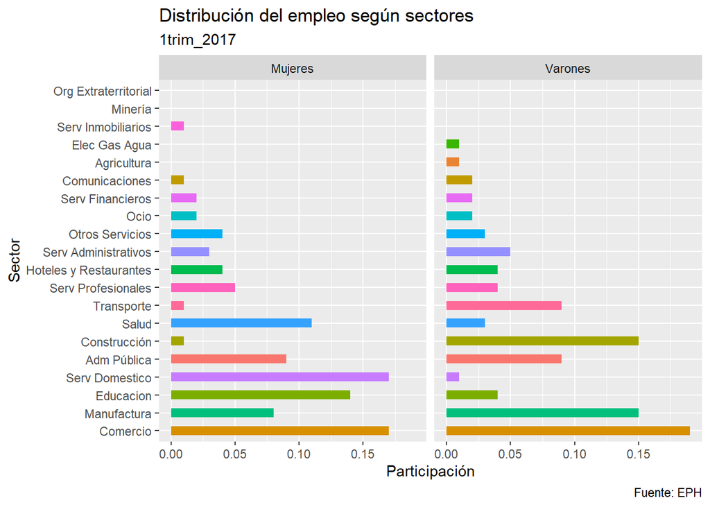

```r
ocupados_sector_genero<-data %>%
  filter(ESTADO==1, PP04B_COD %in% c(0101:9900))%>%
  group_by(sector_actividad)%>%
  summarise(Ocupados_sector_v    =sum(PONDERA[CH04==1]),
            Ocupados_sector_m    =sum(PONDERA[CH04==2]))%>%
  mutate(Participacion_varones= Ocupados_sector_v/sum(Ocupados_sector_v),
         Participacion_mujeres= Ocupados_sector_m/sum(Ocupados_sector_m)) %>%
  select(-c(2,3)) %>%
  mutate(Participacion_varones=round(Participacion_varones,2),
         Participacion_mujeres=round(Participacion_mujeres,2))%>%
  rename(Varones=Participacion_varones,
         Mujeres=Participacion_mujeres)%>%
  gather(.,
         key=Género,
         value=Participación,
         2:3)

grafico2<-ggplot(ocupados_sector_genero, aes(x=reorder(sector_actividad,-Participación),y=Participación, fill=sector_actividad))+
  geom_bar(stat="identity", width=0.5)+
  labs(x = "Sector",
       y = "Participación",
       title = "Distribución del empleo según sectores",
       subtitle = "1trim_2017",
       caption = "Fuente: EPH")+
  theme(legend.position = 'none')+
  facet_wrap(~Género)

grafico2 + coord_flip()
```

Como se puede observar, el empleo femenino se encuentra explicado por el servicio doméstico, el comercio, la educación y la salud, mientras que el empleo masculino se encuentra explicado por el comercio, la construcción, la manufactura.

Otra manera de describir el mismo fenómeno sería observando la participación de cada género en el total del empleo de cada uno de los sectores de actividad.

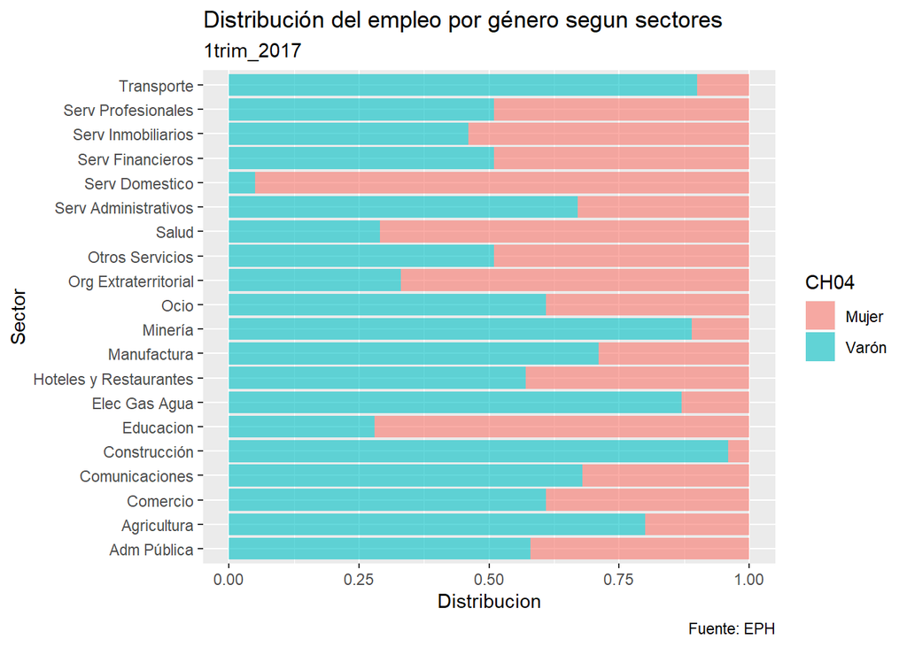

```r
ocupados_genero_sector<-data %>%
  filter(ESTADO==1, PP04B_COD %in% c(0101:9900))%>%
  group_by(sector_actividad,CH04)%>%
  summarise(Ocupados_sector    =sum(PONDERA))%>%
  mutate(Participacion= Ocupados_sector/sum(Ocupados_sector)) %>%
  select(-3) %>%
  mutate(Participacion=round(Participacion,2),
         CH04 = case_when(CH04 == 1 ~ "Varón",
                          CH04 == 2 ~ "Mujer"))

grafico3<- ggplot(ocupados_genero_sector, aes(sector_actividad, Participacion, fill= CH04))+
  geom_col(position = "stack", alpha=0.6)+
  labs(x = "Sector",
       y = "Distribucion",
       title = "Distribución del empleo por género segun sectores",
       subtitle = "1trim_2017",
       caption = "Fuente: EPH")

grafico3 + coord_flip()
```

Los graficos2 y grafico3 confirmarían la hipótesis de que las mujeres tienen una ventaja comparativa en los servicios, mientras que los varones tienen ventajas en actividades industriales y la construcción. Las razones detras de estos resultados puden ser múltiples, como ser, niveles de educación, uso de fuerza física en el trabajo, cantidad de horas mínimas de trabajo, etc.